# Power Analysis for DID design

## Introduction

DID research designs typically assume some autocorrelation structure between observations taken across time. As such, power requirements are often less stringent.

To help us take on power calculations for this purpose, we employ `power_panel.r`, an R-shiny application that makes it easy even for a layperson to tackle it. Here, I document how one can go about installing, running, and drawing conclusions from the application’s output.

## Installing the application

The application is developed by Peter Z. Schochet and published here: https://doi.org/10.3102/10769986211070625

To install the application, head to the published URL and download the supplemental file suffixed `.r`, saving this as `power_panel.r` (or any other name, but note you will need to call this file by its given name in a later step).

### Installing dependencies

The application depends on a number of other R packages in order to run at all. In R, install and load the following libraries.

```r
# Install the following R dependencies if they're missing
install.packages(c("shiny",
                   "shinydashboard",
                   "ggplot2",
                   "kableExtra",
                   "ggtext",
                   "scales"))

# Load these dependencies in R
library(shiny)
library(shinydashboard)
library(ggplot2)
library(kableExtra)
library(ggtext)
library(scales)
```

## Launching the application

We launch the application in R after loading the aforementioned dependencies with the following code:

```r
# You may need to identify and specify the path where you installed `power_panel.r`
  # Mine is in the 'Downloads' folder
  shiny::runApp("~/Downloads/power_panel.r")
```

This should launch the application in a new window with input options that you need to specify for the power calculations

## Interpreting the input options

### 1. Key design information

#### Design type

We choose `Difference-in-differences (DID)`.

#### Type of power analysis

We choose the second option `Calculate the number of clusters required to achieve a target MDE value`. Note that clusters in our case refers to the count of total unique individuals/observations at each time point.

#### Target MDE value

MDE refers to the “minimum detectable effect” and is calculated in terms of standard deviations away from the null (no effect in either direction in our case). Refer to the Z-table to retrieve the MDE associated with the effect you’re powering for. For instance, an MDE of 0.48 translates to a ~20% change in either direction.

#### Type of panel data

Cross-sectional = repeated cross sections of different persons at each time point. Longitudinal = following the same persons over every time point.

### 2. Time periods and intervals

#### Number of time periods

How many distinct time points will you be collecting/observing data?

#### Spacing of time intervals

If not evenly spaced, you can specify how far apart each time point is.

### 3. Treatment timing groups

#### Number of treatment timing groups

Allows an integer larger than 1 if there’s staggered treatment rollout.

#### Start period of each timing group, separated by commas (integers from 2 to the number of time periods)

Only specify a single integer if there’s 1 treatment timing group (no staggered rollout). Otherwise, indicate the start points for each treated group. Note that integers have to start from 2 because it demands at least 1 baseline time point.

#### Desired post-treatment period for the power analysis

Average across all post-periods = pooled ATT Single post-period time point = ATT for a specific time point

### 4. Sample sizes: Clusters are the unit of treatment assignment, such as state, school, or hospital

#### Proportion of all clusters that are treatment clusters (0 to 1)

This is asking for the ratio of treatment to control units. If you’d like 100 treated persons and 100 control persons, the proportion you’d provide here is 0.5.

#### Proportion of treatment clusters in each timing group, separated by commas (0 to 1; must sum to 1)

This value is always 1 if there’s only 1 treatment timing group (no staggered rollout). Otherwise, indicate the proportion of each staggered treatment group.

#### Proportion of matched comparison clusters to each timing group

This value is always 1 if there’s only 1 treatment timing group (no staggered rollout). Otherwise, indicate the proportion of each staggered comparison group.

#### Number of individuals per cluster per time period (integer)

Because we are powering for the number of individuals, this value is 1. If we’re powering for clusters of individuals, this value would change.

### 5. Error structure

#### Autocorrelation structure of cluster-level erorrs over time

We’re assuming an autocorrelation structure here. We have the option of AR1, constant, and no autocorrelation.

#### Autocorrelation parameter (0 to 1)

Assume and provide the autocorrelation coefficient (1 being perfect autocorrelation).

#### Clustering effect: Intraclass correlation coeff. (ICC) within cluster-time cells (0 to 1)

How much between- versus within- correlation over time? We assume ICC to be 0.

### 6. Weights

#### Design effect (variance inflation factor) due to various forms of weighting (at least 1)

Assumed to be 1.

### 7. Precision gains from model covariates

#### Regression R2 value from model covariates that improves precision (0 to 1)

No a priori insertion available. Assumed to be 0.

#### Correlation between model treatment indicators and covariates that reduces precision (0 to 1)

Ditto. Assumed to be 0.

### 8. Hypothesis testing parameters

#### Significance (alpha) level (0 to 1)

We pick the conventional threshold of 0.05.

#### Power level range: Calculations are conducted between min and max values

The resulting output provides power calculations for each interval (next option) between the power level range indicated here.

#### Power level interval

See previous.

## Interpreting the output

After submitting the input options in the application, something like this should show up on it:

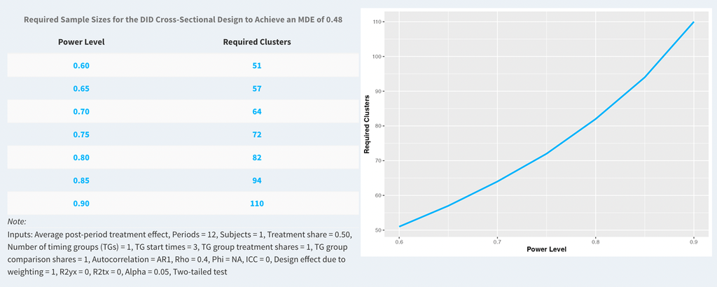

To interpret this, the table on the left provides the power calculations for each power level. If we’re powering for 90%, we would look at the last row and conclude that we would require 110 observations/persons for each of our time points. Note 110 is the total sample size, including control observations/persons. Table captions include a summarized version of the key input options provided for the application to determine these power calculations.

The figure to the right of the table is a simple x-y plot of sample size requirements at each power level between the range specified in the input options.